# Celtic Seas

#### Figure 2

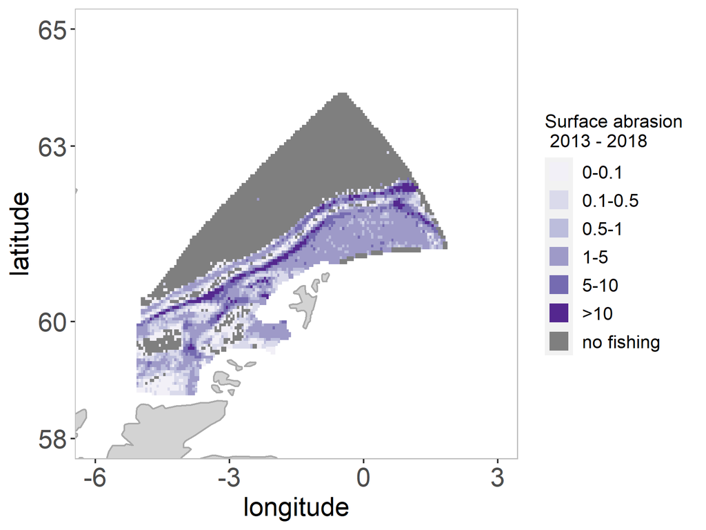

**Figure 2 Fishing intensity, Swept Area Ratio, by mobile bottom-contacting gears (year-1), averaged for the 2013-2018 six-year cycle**

#### Table 2

Table 2 Overview of pressure indicators of all mobile bottom-contacting gears per broad-scale habitat averaged for 2013-2018. I refers to the indicators in Table 1.

| MSFD broad habitat type | Extent of habitat 1000 km2 | Number of grid cells | Landings 1000 tonnes | Value 10 6 euro | Swept area 1000 km2 | Average fishing intensity I 1 | Prop of grid cells fished I 2 | Prop of area fished I 3 | Prop of habitat fished with 90 of effort I 4 |
| --- | --- | --- | --- | --- | --- | --- | --- | --- | --- |
| Upper bathyal sediment | 32.97 | 2226 | 27.89 | 15.23 | 69.87 | 2.11 | 0.51 | 0.39 | 0.24 |
| Lower bathyal sediment | 21.37 | 1490 | 0.00 | 0.00 | 0.01 | 0.00 | 0.00 | 0.00 | 0.00 |
| Offshore circalittoral sand | 17.15 | 1124 | 15.52 | 16.06 | 42.26 | 2.47 | 0.95 | 0.81 | 0.58 |
| Offshore circalittoral coarse sediment | 14.28 | 915 | 6.46 | 9.32 | 16.05 | 1.14 | 0.85 | 0.47 | 0.37 |
| Offshore circalittoral mud | 0.82 | 54 | 1.21 | 1.69 | 3.41 | 4.09 | 1.00 | 0.95 | 0.70 |
| Circalittoral coarse sediment | 0.53 | 33 | 0.03 | 0.06 | 0.07 | 0.13 | 0.97 | 0.13 | 0.58 |
| Lower bathyal sediment or Lower bathyal rock and biogenic reef | 0.47 | 34 | 0.00 | 0.00 | 0.00 | 0.00 | 0.00 | 0.00 | NA |
| Offshore circalittoral mixed sediment | 0.23 | 15 | 0.19 | 0.16 | 0.54 | 2.38 | 0.87 | 0.67 | NA |
| Circalittoral rock and biogenic reef | 0.21 | 13 | 0.07 | 0.12 | 0.11 | 0.55 | 0.92 | 0.40 | NA |
| Upper bathyal sediment or Upper bathyal rock and biogenic reef | 0.19 | 13 | 0.00 | 0.00 | 0.00 | 0.00 | 0.00 | 0.00 | NA |
| Offshore circalittoral rock and biogenic reef | 0.14 | 9 | 0.02 | 0.04 | 0.03 | 0.18 | 0.78 | 0.18 | NA |
| Unknown | 0.09 | 6 | 0.01 | 0.02 | 0.03 | 0.31 | 0.50 | 0.31 | NA |
| Abyssal | 0.03 | 2 | 0.00 | 0.00 | 0.00 | 0.00 | 0.00 | 0.00 | NA |
| Circalittoral sand | 0.02 | 1 | 0.00 | 0.00 | 0.00 | 0.03 | 1.00 | 0.03 | NA |

#### Figure 3

[figure not shown]

**Figure 3. Time series of (a) mean fishing intensity (surface abrasion), (b) proportion of the surface area of the seafloor fished, (c) aggregation of fishing (proportion of the surface area with 90% of the fishing effort) by habitat. Results represent vessels over 15m (2009-2011) and vessels over 12m (2012-2018).**